# Tresthor *Package R pour la prévision économique* Rapport des Tests Économétriques

# 9 Equation Indice des prix à l’énergie : `eq_ipc_nrj`

## 9.1 `ipc_nrj`

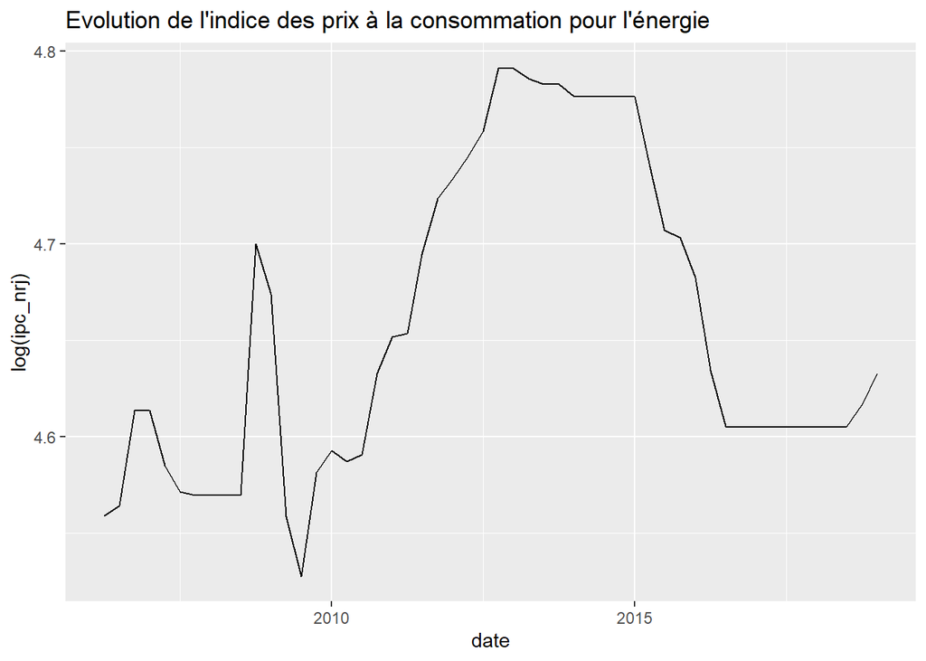

```r
ggplot(data = dt_pf1
       , aes(x =date, y=log(ipc_nrj))) +
  geom_line() +
  ggtitle(paste0("Evolution de l'indice des prix à la consommation pour l'énergie"))
```

```r
a <- ur.df(log(dt_pf1$ipc_nrj),
           lags = 6,
           selectlags = "AIC",
           type = "trend")
summary(a)
```

```
##
## ###############################################
## # Augmented Dickey-Fuller Test Unit Root Test #
## ###############################################
##
## Test regression trend
##
##
## Call:
## lm(formula = z.diff ~ z.lag.1 + 1 + tt + z.diff.lag)
##
## Residuals:
##       Min        1Q    Median        3Q       Max
## -0.080342 -0.012096 -0.000931  0.010653  0.116697
##
## Coefficients:
##               Estimate Std. Error t value Pr(>|t|)
## (Intercept)  0.3778210  0.2707537   1.395  0.17078
## z.lag.1     -0.0790387  0.0585796  -1.349  0.18504
## tt          -0.0002635  0.0003616  -0.729  0.47056
## z.diff.lag1  0.3887551  0.1580517   2.460  0.01844 *
## z.diff.lag2 -0.4609850  0.1460511  -3.156  0.00308 **
## z.diff.lag3  0.2422383  0.1548653   1.564  0.12585
## ---
## Signif. codes:  0 '***' 0.001 '**' 0.01 '*' 0.05 '.' 0.1 ' ' 1
##
## Residual standard error: 0.02908 on 39 degrees of freedom
## Multiple R-squared:  0.3088, Adjusted R-squared:  0.2202
## F-statistic: 3.485 on 5 and 39 DF,  p-value: 0.01065
##
##
## Value of test-statistic is: -1.3493 1.0674 1.5566
##
## Critical values for test statistics:
##       1pct  5pct 10pct
## tau3 -4.04 -3.45 -3.15
## phi2  6.50  4.88  4.16
## phi3  8.73  6.49  5.47
```

```r
b <- ur.df(log(dt_pf1$ipc_nrj),
           lags = 6,
           selectlags = "AIC",
           type = "drift")
summary(b)
```

```
##
## ###############################################
## # Augmented Dickey-Fuller Test Unit Root Test #
## ###############################################
##
## Test regression drift
##
##
## Call:
## lm(formula = z.diff ~ z.lag.1 + 1 + z.diff.lag)
##
## Residuals:
##       Min        1Q    Median        3Q       Max
## -0.079112 -0.007816 -0.000035  0.009291  0.120606
##
## Coefficients:
##             Estimate Std. Error t value Pr(>|t|)
## (Intercept)  0.42415    0.26163   1.621  0.11284
## z.lag.1     -0.09061    0.05605  -1.616  0.11386
## z.diff.lag1  0.41881    0.15168   2.761  0.00865 **
## z.diff.lag2 -0.44657    0.14385  -3.104  0.00350 **
## z.diff.lag3  0.26820    0.14983   1.790  0.08102 .
## ---
## Signif. codes:  0 '***' 0.001 '**' 0.01 '*' 0.05 '.' 0.1 ' ' 1
##
## Residual standard error: 0.02891 on 40 degrees of freedom
## Multiple R-squared:  0.2994, Adjusted R-squared:  0.2294
## F-statistic: 4.274 on 4 and 40 DF,  p-value: 0.005669
##
##
## Value of test-statistic is: -1.6164 1.3515
##
## Critical values for test statistics:
##       1pct  5pct 10pct
## tau2 -3.51 -2.89 -2.58
## phi1  6.70  4.71  3.86
```

```r
c <- ur.df(log(dt_pf1$ipc_nrj),
           lags = 6,
           selectlags = "AIC",
           type = "none")
summary(c)
```

```
##
## ###############################################
## # Augmented Dickey-Fuller Test Unit Root Test #
## ###############################################
##
## Test regression none
##
##
## Call:
## lm(formula = z.diff ~ z.lag.1 - 1 + z.diff.lag)
##
## Residuals:
##       Min        1Q    Median        3Q       Max
## -0.076145 -0.008952 -0.000961  0.009220  0.129551
##
## Coefficients:
##               Estimate Std. Error t value Pr(>|t|)
## z.lag.1      0.0002525  0.0009419   0.268   0.7900
## z.diff.lag1  0.3736789  0.1520348   2.458   0.0183 *
## z.diff.lag2 -0.4901901  0.1440940  -3.402   0.0015 **
## z.diff.lag3  0.2292009  0.1507903   1.520   0.1362
## ---
## Signif. codes:  0 '***' 0.001 '**' 0.01 '*' 0.05 '.' 0.1 ' ' 1
##
## Residual standard error: 0.02947 on 41 degrees of freedom
## Multiple R-squared:  0.2548, Adjusted R-squared:  0.1821
## F-statistic: 3.504 on 4 and 41 DF,  p-value: 0.01499
##
##
## Value of test-statistic is: 0.2681
##
## Critical values for test statistics:
##      1pct  5pct 10pct
## tau1 -2.6 -1.95 -1.61
```

Nous acceptons l’hypothèse nulle de non-stationarité dans un modèle sans constante ni dérive temporelle.

## 9.2 `petrole`

Nous étudions maintenant la variable `petrole` directement issu du site de l’ISPF afin d’obtenir des données davantage en lien avec l’économie Polynésienne. Le prix à la pompe étant fixé en Polynésie, il est en effet difficile de se baser sur des indicateurs comme le brent.

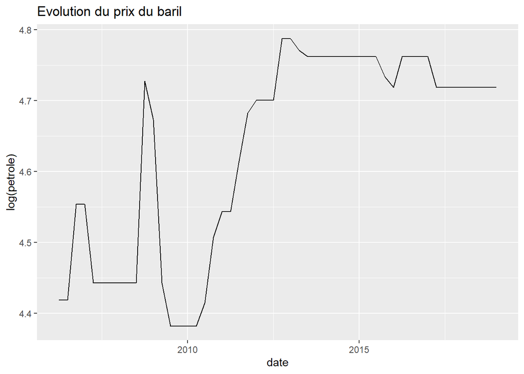

```r
ggplot(data = dt_pf1
       , aes(x =date, y=log(petrole))) +
  geom_line() +
  ggtitle(paste0("Evolution du prix du baril"))
```

```r
a <- ur.df(log(dt_pf1$petrole),
           lags = 6,
           selectlags = "AIC",
           type = "trend")
summary(a)
```

```
##
## ###############################################
## # Augmented Dickey-Fuller Test Unit Root Test #
## ###############################################
##
## Test regression trend
##
##
## Call:
## lm(formula = z.diff ~ z.lag.1 + 1 + tt + z.diff.lag)
##
## Residuals:
##       Min        1Q    Median        3Q       Max
## -0.123251 -0.022097  0.000375  0.010361  0.259820
##
## Coefficients:
##               Estimate Std. Error t value Pr(>|t|)
## (Intercept)  0.7935284  0.4682240   1.695   0.0979 .
## z.lag.1     -0.1751230  0.1061960  -1.649   0.1070
## tt           0.0009399  0.0011039   0.851   0.3996
## z.diff.lag1  0.2460592  0.1493049   1.648   0.1072
## z.diff.lag2 -0.2809239  0.1547343  -1.816   0.0769 .
## ---
## Signif. codes:  0 '***' 0.001 '**' 0.01 '*' 0.05 '.' 0.1 ' ' 1
##
## Residual standard error: 0.05798 on 40 degrees of freedom
## Multiple R-squared:  0.2214, Adjusted R-squared:  0.1436
## F-statistic: 2.844 on 4 and 40 DF,  p-value: 0.03637
##
##
## Value of test-statistic is: -1.6491 1.338 1.6474
##
## Critical values for test statistics:
##       1pct  5pct 10pct
## tau3 -4.04 -3.45 -3.15
## phi2  6.50  4.88  4.16
## phi3  8.73  6.49  5.47
```

```r
b <- ur.df(log(dt_pf1$petrole),
           lags = 6,
           selectlags = "AIC",
           type = "drift")
summary(b)
```

```
##
## ###############################################
## # Augmented Dickey-Fuller Test Unit Root Test #
## ###############################################
##
## Test regression drift
##
##
## Call:
## lm(formula = z.diff ~ z.lag.1 + 1 + z.diff.lag)
##
## Residuals:
##       Min        1Q    Median        3Q       Max
## -0.129779 -0.014243  0.000869  0.006046  0.256389
##
## Coefficients:
##             Estimate Std. Error t value Pr(>|t|)
## (Intercept)  0.48690    0.29825   1.633   0.1102
## z.lag.1     -0.10322    0.06417  -1.608   0.1154
## z.diff.lag1  0.20742    0.14176   1.463   0.1511
## z.diff.lag2 -0.32898    0.14359  -2.291   0.0272 *
## ---
## Signif. codes:  0 '***' 0.001 '**' 0.01 '*' 0.05 '.' 0.1 ' ' 1
##
## Residual standard error: 0.05778 on 41 degrees of freedom
## Multiple R-squared:  0.2073, Adjusted R-squared:  0.1493
## F-statistic: 3.574 on 3 and 41 DF,  p-value: 0.02191
##
##
## Value of test-statistic is: -1.6084 1.6556
##
## Critical values for test statistics:
##       1pct  5pct 10pct
## tau2 -3.51 -2.89 -2.58
## phi1  6.70  4.71  3.86
```

```r
c <- ur.df(log(dt_pf1$petrole),
           lags = 6,
           selectlags = "AIC",
           type = "none")
summary(c)
```

```
##
## ###############################################
## # Augmented Dickey-Fuller Test Unit Root Test #
## ###############################################
##
## Test regression none
##
##
## Call:
## lm(formula = z.diff ~ z.lag.1 - 1 + z.diff.lag)
##
## Residuals:
##       Min        1Q    Median        3Q       Max
## -0.119729 -0.012766 -0.007089  0.009414  0.278062
##
## Coefficients:
##              Estimate Std. Error t value Pr(>|t|)
## z.lag.1      0.001502   0.001906   0.788   0.4350
## z.diff.lag1  0.173249   0.142963   1.212   0.2323
## z.diff.lag2 -0.379356   0.142990  -2.653   0.0112 *
## ---
## Signif. codes:  0 '***' 0.001 '**' 0.01 '*' 0.05 '.' 0.1 ' ' 1
##
## Residual standard error: 0.05892 on 42 degrees of freedom
## Multiple R-squared:  0.164,  Adjusted R-squared:  0.1043
## F-statistic: 2.746 on 3 and 42 DF,  p-value: 0.05482
##
##
## Value of test-statistic is: 0.7882
##
## Critical values for test statistics:
##      1pct  5pct 10pct
## tau1 -2.6 -1.95 -1.61
```

Nous acceptons l’hypothèse nulle de non-stationarité dans un modèle sans constante ni dérive temporelle.

## 9.3 Regression de la relation de long terme

```r
reg_ipc_nrj_lt1 <- lm(log(ipc_nrj) ~ log(petrole), dt_pf1)
summary(reg_ipc_nrj_lt1)
```

```
##
## Call:
## lm(formula = log(ipc_nrj) ~ log(petrole), data = dt_pf1)
##
## Residuals:
##      Min       1Q   Median       3Q      Max
## -0.10424 -0.02504  0.00184  0.04695  0.07388
##
## Coefficients:
##              Estimate Std. Error t value           Pr(>|t|)
## (Intercept)   2.80787    0.25798  10.884 0.0000000000000086 ***
## log(petrole)  0.39932    0.05568   7.172 0.0000000032274828 ***
## ---
## Signif. codes:  0 '***' 0.001 '**' 0.01 '*' 0.05 '.' 0.1 ' ' 1
##
## Residual standard error: 0.05774 on 50 degrees of freedom
## Multiple R-squared:  0.5071, Adjusted R-squared:  0.4972
## F-statistic: 51.44 on 1 and 50 DF,  p-value: 0.000000003227
```

```r
reg_ipc_nrj_lt2 <- lm(log(ipc_nrj) ~ log(brent), dt_pf1)
summary(reg_ipc_nrj_lt2)
```

```
##
## Call:
## lm(formula = log(ipc_nrj) ~ log(brent), data = dt_pf1)
##
## Residuals:
##       Min        1Q    Median        3Q       Max
## -0.151963 -0.048118 -0.009617  0.070465  0.124030
##
## Coefficients:
##             Estimate Std. Error t value             Pr(>|t|)
## (Intercept)  4.08560    0.12627   32.36 < 0.0000000000000002 ***
## log(brent)   0.13228    0.02914    4.54            0.0000356 ***
## ---
## Signif. codes:  0 '***' 0.001 '**' 0.01 '*' 0.05 '.' 0.1 ' ' 1
##
## Residual standard error: 0.06921 on 50 degrees of freedom
## Multiple R-squared:  0.2919, Adjusted R-squared:  0.2778
## F-statistic: 20.61 on 1 and 50 DF,  p-value: 0.00003558
```

```r
reg_ipc_nrj_lt3 <- lm(log(ipc_nrj) ~ log(petrole) + log(brent), dt_pf1)
summary(reg_ipc_nrj_lt3)
```

```
##
## Call:
## lm(formula = log(ipc_nrj) ~ log(petrole) + log(brent), data = dt_pf1)
##
## Residuals:
##       Min        1Q    Median        3Q       Max
## -0.084319 -0.037704  0.009417  0.027454  0.071113
##
## Coefficients:
##              Estimate Std. Error t value             Pr(>|t|)
## (Intercept)   2.32826    0.19098  12.191 < 0.0000000000000002 ***
## log(petrole)  0.38651    0.03879   9.965    0.000000000000226 ***
## log(brent)    0.12471    0.01693   7.365    0.000000001809879 ***
## ---
## Signif. codes:  0 '***' 0.001 '**' 0.01 '*' 0.05 '.' 0.1 ' ' 1
##
## Residual standard error: 0.04019 on 49 degrees of freedom
## Multiple R-squared:  0.7661, Adjusted R-squared:  0.7565
## F-statistic: 80.23 on 2 and 49 DF,  p-value: 0.0000000000000003493
```

La combination des deux variables permet d’expliquer 3/4 de la variance de la variable dépendante. Les coefficients sont de plus significatif et du signe cohérent. Les deux variables se complètent car elle permettent d’avoir deux niveaux différents d’analyse des chocs et des variations.

## 9.4 Tests de cointégration

```r
res1_ipc_nrj <- resid(reg_ipc_nrj_lt1)
reg_ipc_nrj_res1 <-
  ur.df(res1_ipc_nrj,
        lags = 6,
        type = "none",
        selectlags = "AIC")
summary(reg_ipc_nrj_res1)
```

```
##
## ###############################################
## # Augmented Dickey-Fuller Test Unit Root Test #
## ###############################################
##
## Test regression none
##
##
## Call:
## lm(formula = z.diff ~ z.lag.1 - 1 + z.diff.lag)
##
## Residuals:
##       Min        1Q    Median        3Q       Max
## -0.042991 -0.009192  0.001093  0.006469  0.048254
##
## Coefficients:
##             Estimate Std. Error t value Pr(>|t|)
## z.lag.1     -0.05426    0.04046  -1.341 0.187262
## z.diff.lag1  0.57250    0.14816   3.864 0.000389 ***
## z.diff.lag2 -0.38890    0.15418  -2.522 0.015634 *
## z.diff.lag3  0.34295    0.14716   2.331 0.024779 *
## ---
## Signif. codes:  0 '***' 0.001 '**' 0.01 '*' 0.05 '.' 0.1 ' ' 1
##
## Residual standard error: 0.01497 on 41 degrees of freedom
## Multiple R-squared:  0.303,  Adjusted R-squared:  0.235
## F-statistic: 4.455 on 4 and 41 DF,  p-value: 0.004414
##
##
## Value of test-statistic is: -1.3411
##
## Critical values for test statistics:
##      1pct  5pct 10pct
## tau1 -2.6 -1.95 -1.61
```

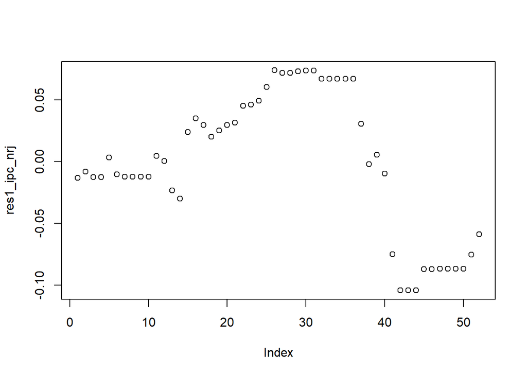

```r
plot(res1_ipc_nrj)
```

```r
res2_ipc_nrj <- resid(reg_ipc_nrj_lt2)
reg_ipc_nrj_res2 <-
  ur.df(res2_ipc_nrj,
        lags = 6,
        type = "none",
        selectlags = "AIC")
summary(reg_ipc_nrj_res2)
```

```
##
## ###############################################
## # Augmented Dickey-Fuller Test Unit Root Test #
## ###############################################
##
## Test regression none
##
##
## Call:
## lm(formula = z.diff ~ z.lag.1 - 1 + z.diff.lag)
##
## Residuals:
##       Min        1Q    Median        3Q       Max
## -0.057854 -0.014821  0.003484  0.018135  0.122611
##
## Coefficients:
##             Estimate Std. Error t value Pr(>|t|)
## z.lag.1     -0.10758    0.07309  -1.472  0.14849
## z.diff.lag1  0.20979    0.13807   1.519  0.13614
## z.diff.lag2 -0.39120    0.14008  -2.793  0.00784 **
## ---
## Signif. codes:  0 '***' 0.001 '**' 0.01 '*' 0.05 '.' 0.1 ' ' 1
##
## Residual standard error: 0.03171 on 42 degrees of freedom
## Multiple R-squared:  0.2556, Adjusted R-squared:  0.2024
## F-statistic: 4.807 on 3 and 42 DF,  p-value: 0.005745
##
##
## Value of test-statistic is: -1.4719
##
## Critical values for test statistics:
##      1pct  5pct 10pct
## tau1 -2.6 -1.95 -1.61
```

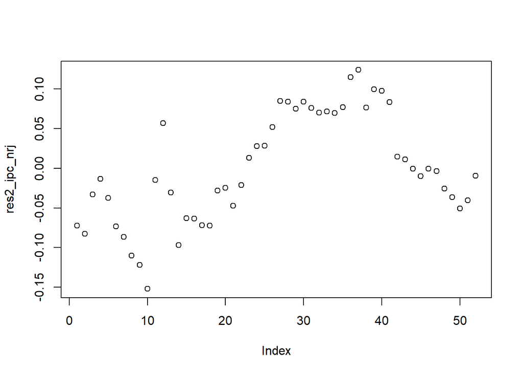

```r
plot(res2_ipc_nrj)
```

```r
res3_ipc_nrj <- resid(reg_ipc_nrj_lt3)
reg_ipc_nrj_res3 <-
  ur.df(res3_ipc_nrj,
        lags = 6,
        type = "none",
        selectlags = "AIC")
summary(reg_ipc_nrj_res3)
```

```
##
## ###############################################
## # Augmented Dickey-Fuller Test Unit Root Test #
## ###############################################
##
## Test regression none
##
##
## Call:
## lm(formula = z.diff ~ z.lag.1 - 1 + z.diff.lag)
##
## Residuals:
##       Min        1Q    Median        3Q       Max
## -0.053355 -0.013644 -0.000157  0.007483  0.070328
##
## Coefficients:
##            Estimate Std. Error t value Pr(>|t|)
## z.lag.1    -0.21121    0.09027  -2.340    0.024 *
## z.diff.lag  0.23322    0.15491   1.505    0.140
## ---
## Signif. codes:  0 '***' 0.001 '**' 0.01 '*' 0.05 '.' 0.1 ' ' 1
##
## Residual standard error: 0.02324 on 43 degrees of freedom
## Multiple R-squared:  0.1225, Adjusted R-squared:  0.08165
## F-statistic:     3 on 2 and 43 DF,  p-value: 0.06029
##
##
## Value of test-statistic is: -2.3398
##
## Critical values for test statistics:
##      1pct  5pct 10pct
## tau1 -2.6 -1.95 -1.61
```

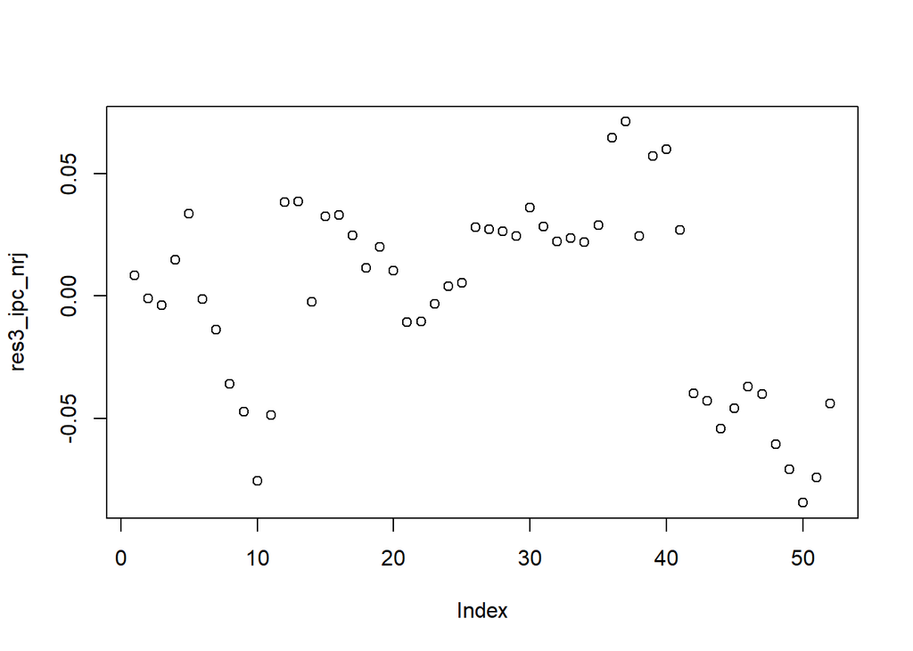

```r
plot(res3_ipc_nrj)
```

Individuellement, les variables ne sont pas cointégrées avec `ipc_nrj`. Cependant, l’hypothèse nulle d’absence de cointégration est rejetée pour la combinaison des deux variables explicatives.

## 9.5 Détermination de la spécification

```r
create_equation(
  equation_name = "eq_ipc_nrj",
  formula = "delta(1,log(ipc_nrj))=h_cst+h_0*(log(lag(ipc_nrj,-1))-h_lt1-h_lt2*log(lag(petrole,-1))-h_lt3*log(lag(brent,-1)))+h_1*delta(1,log(petrole))+h_2*delta(1,log(brent))+delta(1,af_eq_ipc_nrj)-h_0*lag(af_eq_ipc_nrj,-1)",
  coefflist = c("h_cst", "h_0", "h_1", "h_2", "h_3", "h_lt2", "h_lt1", "h_lt3"),
  endogenous = "ipc_nrj"
)
```

```
## The following coefficients were not found in the formula:[1] "h_3"
##
## Equation variables identified :
## af_eq_ipc_nrj brent h_0 h_1 h_2 h_cst h_lt1 h_lt2 h_lt3 ipc_nrj petrole
##  Exogenous variables :
## af_eq_ipc_nrj brent petrole
##  Coefficients parser error, the formula may be difficult to use in econometric estimations.
##  RHS of equation does not appear to be ok for econometric estimations with the current coefficient list.
```

```r
estimation <-
  quick_estim(
    thor_equation = eq_ipc_nrj ,
    database = dt_pf,
    estim_start = as.Date(date_debut_estim),
    estim_end = as.Date(date_fin_estim),
    coeff_lt = c("h_lt1", "h_lt2", "h_lt3"),
    const = T
  )
```

```
##
##  --------------- Estimating equation: eq_ipc_nrj ---------------
##
##
##  Estimation du long-terme :
##
## ### D-OLS model ###
##
## Model:       sub_database[c(index_start:index_end), yt] ~ c(rep(1, (index_end - index_start + 1))) + sub_database[c(index_start:index_end), xt]
##
## Parameters:  Kernel = "qs"  //  Bandwidth = 7.982669 ("Andrews")
##
##      Leads = 2 / Lags = 2 (set manually)
##
## Coefficients:
##             Estimate  Std.Err t value          Pr(|t|>0)
## deter       2.408130 0.236297 10.1911 0.0000000000000282 ***
## log.petrole 0.327326 0.048403  6.7625 0.0000000092343545 ***
## log.brent   0.169911 0.023512  7.2267 0.0000000016035606 ***
## ---
## Signif. codes:  0 '***' 0.001 '**' 0.01 '*' 0.05 '.' 0.1 ' ' 1
## delta(1,log(ipc_nrj))=h_cst+h_0*(log(lag(ipc_nrj,-1))-2.4081295795-0.3273262886*log(lag(petrole,-1))-0.1699109026*log(lag(brent,-1)))+h_1*delta(1,log(petrole))+h_2*delta(1,log(brent))+delta(1,af_eq_ipc_nrj)-h_0*lag(af_eq_ipc_nrj,-1)
##
##  Estimation du court-terme :
##
## Call:
## lm(formula = eval(parse(text = formula_ols)), data = plop)
##
## Residuals:
##       Min        1Q    Median        3Q       Max
## -0.036466 -0.006686 -0.000324  0.006206  0.049824
##
## Coefficients: (1 not defined because of singularities)
##                                                                                                                    Estimate
## (Intercept)                                                                                                      -0.0007465
## I(log(lag(ipc_nrj, 1)) - 2.4081295795 - 0.3273262886 * log(lag(petrole, 1)) - 0.1699109026 * log(lag(brent, 1))) -0.2425078
## newdiff(1, log(petrole))                                                                                          0.3675629
## newdiff(1, log(brent))                                                                                            0.0205224
## newdiff(1, af_eq_ipc_nrj)                                                                                                NA
##                                                                                                                  Std. Error
```

[output cut: 15 more lines]

```
## newdiff(1, log(brent))                                                                                                         0.0624
## newdiff(1, af_eq_ipc_nrj)                                                                                                          NA
##
## (Intercept)
## I(log(lag(ipc_nrj, 1)) - 2.4081295795 - 0.3273262886 * log(lag(petrole, 1)) - 0.1699109026 * log(lag(brent, 1))) ***
## newdiff(1, log(petrole))                                                                                         ***
## newdiff(1, log(brent))                                                                                           .
## newdiff(1, af_eq_ipc_nrj)
## ---
## Signif. codes:  0 '***' 0.001 '**' 0.01 '*' 0.05 '.' 0.1 ' ' 1
##
## Residual standard error: 0.01294 on 48 degrees of freedom
##   (1 observation effacée parce que manquante)
## Multiple R-squared:  0.843,  Adjusted R-squared:  0.8331
## F-statistic: 85.89 on 3 and 48 DF,  p-value: < 0.00000000000000022
```

La spécification est très satisfaisante.

# 10 Equation Indice des prix totaux : `eq_ipc_tot`

## 10.1 `ipc_tot`

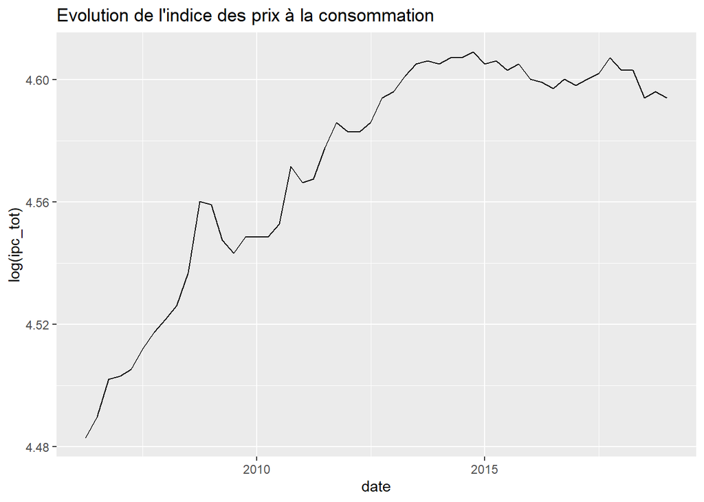

```r
ggplot(data = dt_pf1
       , aes(x =date, y=log(ipc_tot))) +
  geom_line() +
  ggtitle(paste0("Evolution de l'indice des prix à la consommation"))
```

```r
a <- ur.df(log(dt_pf1$ipc_tot),
           lags = 6,
           selectlags = "AIC",
           type = "trend")
summary(a)
```

```
##
## ###############################################
## # Augmented Dickey-Fuller Test Unit Root Test #
## ###############################################
##
## Test regression trend
##
##
## Call:
## lm(formula = z.diff ~ z.lag.1 + 1 + tt + z.diff.lag)
##
## Residuals:
##        Min         1Q     Median         3Q        Max
## -0.0098704 -0.0027450 -0.0002916  0.0026755  0.0167739
##
## Coefficients:
##               Estimate Std. Error t value Pr(>|t|)
## (Intercept)  0.3030265  0.2803465   1.081   0.2867
## z.lag.1     -0.0648158  0.0620838  -1.044   0.3033
## tt          -0.0001123  0.0001550  -0.724   0.4734
## z.diff.lag1  0.1672968  0.1515569   1.104   0.2768
## z.diff.lag2 -0.2234637  0.1515252  -1.475   0.1487
## z.diff.lag3 -0.2622330  0.1540816  -1.702   0.0972 .
## z.diff.lag4  0.2896599  0.1497237   1.935   0.0607 .
## z.diff.lag5 -0.3947100  0.1509960  -2.614   0.0129 *
## ---
## Signif. codes:  0 '***' 0.001 '**' 0.01 '*' 0.05 '.' 0.1 ' ' 1
##
## Residual standard error: 0.005228 on 37 degrees of freedom
## Multiple R-squared:  0.3952, Adjusted R-squared:  0.2808
## F-statistic: 3.454 on 7 and 37 DF,  p-value: 0.006051
##
##
## Value of test-statistic is: -1.044 4.2179 5.2428
##
## Critical values for test statistics:
##       1pct  5pct 10pct
## tau3 -4.04 -3.45 -3.15
## phi2  6.50  4.88  4.16
## phi3  8.73  6.49  5.47
```

```r
b <- ur.df(log(dt_pf1$ipc_tot),
           lags = 6,
           selectlags = "AIC",
           type = "drift")
summary(b)
```

```
##
## ###############################################
## # Augmented Dickey-Fuller Test Unit Root Test #
## ###############################################
##
## Test regression drift
##
##
## Call:
## lm(formula = z.diff ~ z.lag.1 + 1 + z.diff.lag)
##
## Residuals:
##        Min         1Q     Median         3Q        Max
## -0.0098255 -0.0025974 -0.0000048  0.0024038  0.0164293
##
## Coefficients:
##             Estimate Std. Error t value Pr(>|t|)
## (Intercept)  0.47462    0.14899   3.186  0.00288 **
## z.lag.1     -0.10306    0.03245  -3.176  0.00296 **
## z.diff.lag1  0.20631    0.14077   1.466  0.15099
## z.diff.lag2 -0.17573    0.13559  -1.296  0.20278
## z.diff.lag3 -0.22571    0.14469  -1.560  0.12705
## z.diff.lag4  0.32332    0.14144   2.286  0.02792 *
## z.diff.lag5 -0.36699    0.14515  -2.528  0.01573 *
## ---
## Signif. codes:  0 '***' 0.001 '**' 0.01 '*' 0.05 '.' 0.1 ' ' 1
##
## Residual standard error: 0.005195 on 38 degrees of freedom
## Multiple R-squared:  0.3866, Adjusted R-squared:  0.2898
## F-statistic: 3.992 on 6 and 38 DF,  p-value: 0.003405
##
##
## Value of test-statistic is: -3.176 6.1413
##
## Critical values for test statistics:
##       1pct  5pct 10pct
## tau2 -3.51 -2.89 -2.58
## phi1  6.70  4.71  3.86
```

Nous rejetons l’hypothèse nulle de non-stationarité dans un modèle avec constante sans dérive temporelle.

## 10.2 `csu_s11`

Le coût salarié unitaire permet encore une fois de relier le prix du marché du travail au niveau général des prix. Ceci boucle la relation entre `smpt_s11` et `dfl_cf_s14`.

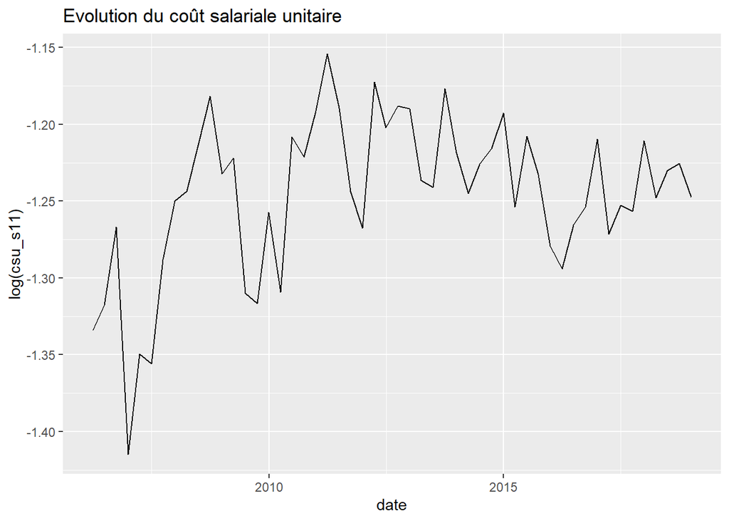

```r
ggplot(data = dt_pf1
       , aes(x =date, y=log(csu_s11))) +
  geom_line() +
  ggtitle(paste0("Evolution du coût salariale unitaire"))
```

```r
a <- ur.df(log(dt_pf1$csu_s11),
           lags = 6,
           selectlags = "AIC",
           type = "trend")
summary(a)
```

```
##
## ###############################################
## # Augmented Dickey-Fuller Test Unit Root Test #
## ###############################################
##
## Test regression trend
##
##
## Call:
## lm(formula = z.diff ~ z.lag.1 + 1 + tt + z.diff.lag)
##
## Residuals:
##       Min        1Q    Median        3Q       Max
## -0.085578 -0.019302  0.001233  0.024743  0.070927
##
## Coefficients:
##               Estimate Std. Error t value Pr(>|t|)
## (Intercept) -0.7428723  0.1968551  -3.774 0.000510 ***
## z.lag.1     -0.6085951  0.1586687  -3.836 0.000424 ***
## tt          -0.0002285  0.0004108  -0.556 0.580968
## z.diff.lag  -0.0367082  0.1415628  -0.259 0.796696
## ---
## Signif. codes:  0 '***' 0.001 '**' 0.01 '*' 0.05 '.' 0.1 ' ' 1
##
## Residual standard error: 0.03556 on 41 degrees of freedom
## Multiple R-squared:  0.3308, Adjusted R-squared:  0.2819
## F-statistic: 6.757 on 3 and 41 DF,  p-value: 0.0008291
##
##
## Value of test-statistic is: -3.8356 5.1205 7.6289
##
## Critical values for test statistics:
##       1pct  5pct 10pct
## tau3 -4.04 -3.45 -3.15
## phi2  6.50  4.88  4.16
## phi3  8.73  6.49  5.47
```

Nous rejetons l’hypothèse nulle de non-stationarité dans un modèle avec constante et dérive temporelle.

## 10.3 Regression de la relation de long terme

```r
reg_ipc_tot_lt1 <- lm(log(ipc_tot) ~ log(csu_s11), dt_pf1)
summary(reg_ipc_tot_lt1)
```

```
##
## Call:
## lm(formula = log(ipc_tot) ~ log(csu_s11), data = dt_pf1)
##
## Residuals:
##       Min        1Q    Median        3Q       Max
## -0.061966 -0.020789  0.005205  0.025164  0.046185
##
## Coefficients:
##              Estimate Std. Error t value             Pr(>|t|)
## (Intercept)    5.0792     0.1034  49.140 < 0.0000000000000002 ***
## log(csu_s11)   0.4067     0.0829   4.906            0.0000103 ***
## ---
## Signif. codes:  0 '***' 0.001 '**' 0.01 '*' 0.05 '.' 0.1 ' ' 1
##
## Residual standard error: 0.03057 on 50 degrees of freedom
## Multiple R-squared:  0.325,  Adjusted R-squared:  0.3115
## F-statistic: 24.07 on 1 and 50 DF,  p-value: 0.00001027
```

Le coût salarié unitaire explique plutôt bien l’indice des prix à la consommation en niveau.

## 10.4 Tests de cointégration

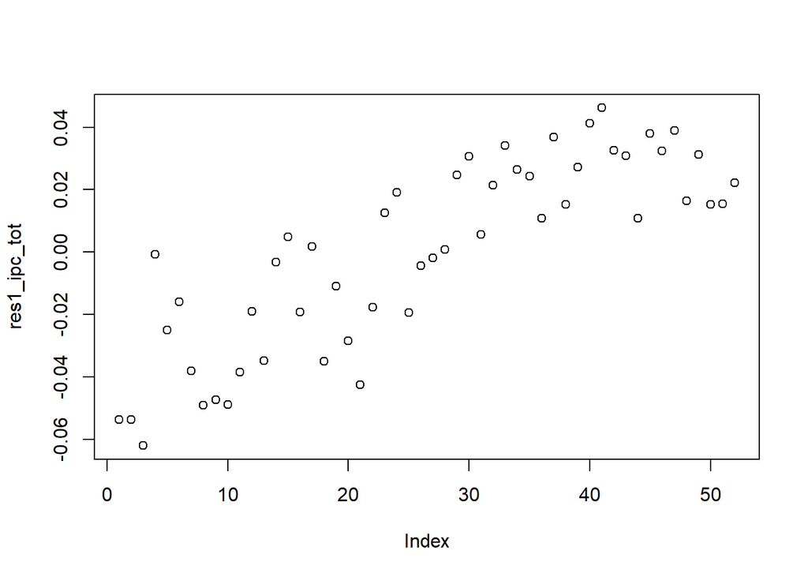

```r
res1_ipc_tot <- resid(reg_ipc_tot_lt1)
plot(res1_ipc_tot)
```

```r
reg_ipc_tot_res1 <-
  ur.df(res1_ipc_tot,
        lags = 6,
        type = "none",
        selectlags = "AIC")
summary(reg_ipc_tot_res1)
```

```
##
## ###############################################
## # Augmented Dickey-Fuller Test Unit Root Test #
## ###############################################
##
## Test regression none
##
##
## Call:
## lm(formula = z.diff ~ z.lag.1 - 1 + z.diff.lag)
##
## Residuals:
##       Min        1Q    Median        3Q       Max
## -0.033675 -0.009064  0.003115  0.015440  0.034648
##
## Coefficients:
##            Estimate Std. Error t value Pr(>|t|)
## z.lag.1    -0.15654    0.09241  -1.694   0.0975 .
## z.diff.lag -0.28674    0.14278  -2.008   0.0509 .
## ---
## Signif. codes:  0 '***' 0.001 '**' 0.01 '*' 0.05 '.' 0.1 ' ' 1
##
## Residual standard error: 0.01654 on 43 degrees of freedom
## Multiple R-squared:  0.1912, Adjusted R-squared:  0.1536
## F-statistic: 5.082 on 2 and 43 DF,  p-value: 0.01044
##
##
## Value of test-statistic is: -1.694
##
## Critical values for test statistics:
##      1pct  5pct 10pct
## tau1 -2.6 -1.95 -1.61
```

Nous rejetons l’hypothèse nulle d’absence de cointégration uniquement au seuil de 10 %. Graphiquement les résidus ont l’air de suivre une tendance.

## 10.5 Détermination de la spécification

```r
create_equation(
  equation_name = "eq_ipc_tot",
  formula = "delta(1,log(ipc_tot))=i_cst+i_0*(log(lag(ipc_tot,-1))-i_lt1-i_lt2*log(lag(csu_s11,-1)))+i_1*delta(1,log(csu_s11))+delta(1,af_eq_ipc_tot)-i_0*lag(af_eq_ipc_tot,-1)",
  coefflist = c("i_cst", "i_0", "i_1", "i_2", "i_3", "i_lt2", "i_lt1", "i_lt3"),
  endogenous = "ipc_tot"
)
```

```
## The following coefficients were not found in the formula:[1] "i_2"   "i_3"   "i_lt3"
##
## Equation variables identified :
## af_eq_ipc_tot csu_s11 i_0 i_1 i_cst i_lt1 i_lt2 ipc_tot
##  Exogenous variables :
## af_eq_ipc_tot csu_s11
##  Coefficients parser error, the formula may be difficult to use in econometric estimations.
##  RHS of equation does not appear to be ok for econometric estimations with the current coefficient list.
```

```r
estimation <-
  quick_estim(
    thor_equation = eq_ipc_tot ,
    database = dt_pf,
    estim_start = as.Date(date_debut_estim),
    estim_end = as.Date(date_fin_estim),
    coeff_lt = c("i_lt1", "i_lt2"),
    const = T
  )
```

```
##
##  --------------- Estimating equation: eq_ipc_tot ---------------
```

```
##
##
##  Estimation du long-terme :
##
## ### D-OLS model ###
##
## Model:       sub_database[c(index_start:index_end), yt] ~ c(rep(1, (index_end - index_start + 1))) + sub_database[c(index_start:index_end), xt]
##
## Parameters:  Kernel = "qs"  //  Bandwidth = 20.71724 ("Andrews")
##
##      Leads = 2 / Lags = 2 (set manually)
##
## Coefficients:
##         Estimate Std.Err t value Pr(|t|>0)
## deter    5.41352      NA      NA        NA
## x.coint  0.67341      NA      NA        NA
## delta(1,log(ipc_tot))=i_cst+i_0*(log(lag(ipc_tot,-1))-5.4135241601-0.6734146268*log(lag(csu_s11,-1)))+i_1*delta(1,log(csu_s11))+delta(1,af_eq_ipc_tot)-i_0*lag(af_eq_ipc_tot,-1)
##
##  Estimation du court-terme :
##
## Call:
## lm(formula = eval(parse(text = formula_ols)), data = plop)
##
## Residuals:
##        Min         1Q     Median         3Q        Max
## -0.0163145 -0.0028005  0.0005134  0.0027432  0.0142057
##
## Coefficients: (1 not defined because of singularities)
##                                                                                Estimate
## (Intercept)                                                                   0.0018433
## I(log(lag(ipc_tot, 1)) - 5.4135241601 - 0.6734146268 * log(lag(csu_s11, 1))) -0.1017351
## newdiff(1, log(csu_s11))                                                      0.0371214
## newdiff(1, af_eq_ipc_tot)                                                            NA
##                                                                              Std. Error
## (Intercept)                                                                   0.0007302
## I(log(lag(ipc_tot, 1)) - 5.4135241601 - 0.6734146268 * log(lag(csu_s11, 1)))  0.0240249
## newdiff(1, log(csu_s11))                                                      0.0169681
## newdiff(1, af_eq_ipc_tot)                                                            NA
##                                                                              t value
## (Intercept)                                                                    2.524
## I(log(lag(ipc_tot, 1)) - 5.4135241601 - 0.6734146268 * log(lag(csu_s11, 1)))  -4.235
## newdiff(1, log(csu_s11))                                                       2.188
## newdiff(1, af_eq_ipc_tot)                                                         NA
##                                                                              Pr(>|t|)
## (Intercept)                                                                    0.0149
## I(log(lag(ipc_tot, 1)) - 5.4135241601 - 0.6734146268 * log(lag(csu_s11, 1)))   0.0001
## newdiff(1, log(csu_s11))                                                       0.0335
## newdiff(1, af_eq_ipc_tot)                                                          NA
##
## (Intercept)                                                                  *
## I(log(lag(ipc_tot, 1)) - 5.4135241601 - 0.6734146268 * log(lag(csu_s11, 1))) ***
## newdiff(1, log(csu_s11))                                                     *
## newdiff(1, af_eq_ipc_tot)
## ---
## Signif. codes:  0 '***' 0.001 '**' 0.01 '*' 0.05 '.' 0.1 ' ' 1
##
## Residual standard error: 0.005227 on 49 degrees of freedom
##   (1 observation effacée parce que manquante)
## Multiple R-squared:  0.2715, Adjusted R-squared:  0.2418
## F-statistic:  9.13 on 2 and 49 DF,  p-value: 0.0004262
```

La spécification est plutôt satisfaisante mais on souhaite améliorer l’explication des dynamiques de court terme grâce à `ipc_alim` et `ipc_nrj`.

```r
create_equation(
  equation_name = "eq_ipc_tot",
  formula = "delta(1,log(ipc_tot))=i_cst+i_0*(log(lag(ipc_tot,-1))-i_lt1-i_lt2*log(lag(csu_s11,-1)))+i_1*delta(1,log(csu_s11))+i_2*delta(1,log(ipc_nrj))+i_3*delta(1,log(ipc_alim))+delta(1,af_eq_ipc_tot)-i_0*lag(af_eq_ipc_tot,-1)",
  coefflist = c("i_cst", "i_0", "i_1", "i_2", "i_3", "i_lt2", "i_lt1", "i_lt3"),
  endogenous = "ipc_tot"
)
```

```
## The following coefficients were not found in the formula:[1] "i_lt3"
##
## Equation variables identified :
## af_eq_ipc_tot csu_s11 i_0 i_1 i_2 i_3 i_cst i_lt1 i_lt2 ipc_alim ipc_nrj ipc_tot
##  Exogenous variables :
## af_eq_ipc_tot csu_s11 ipc_alim ipc_nrj
##  Coefficients parser error, the formula may be difficult to use in econometric estimations.
##  RHS of equation does not appear to be ok for econometric estimations with the current coefficient list.
```

```r
estimation <-
  quick_estim(
    thor_equation = eq_ipc_tot ,
    database = dt_pf,
    estim_start = as.Date(date_debut_estim),
    estim_end = as.Date(date_fin_estim),
    coeff_lt = c("i_lt1", "i_lt2"),
    const = T
  )
```

```
##
##  --------------- Estimating equation: eq_ipc_tot ---------------
```

```
##
##
##  Estimation du long-terme :
##
## ### D-OLS model ###
##
## Model:       sub_database[c(index_start:index_end), yt] ~ c(rep(1, (index_end - index_start + 1))) + sub_database[c(index_start:index_end), xt]
##
## Parameters:  Kernel = "qs"  //  Bandwidth = 20.71724 ("Andrews")
##
##      Leads = 2 / Lags = 2 (set manually)
##
## Coefficients:
##         Estimate Std.Err t value Pr(|t|>0)
## deter    5.41352      NA      NA        NA
## x.coint  0.67341      NA      NA        NA
## delta(1,log(ipc_tot))=i_cst+i_0*(log(lag(ipc_tot,-1))-5.4135241601-0.6734146268*log(lag(csu_s11,-1)))+i_1*delta(1,log(csu_s11))+i_2*delta(1,log(ipc_nrj))+i_3*delta(1,log(ipc_alim))+delta(1,af_eq_ipc_tot)-i_0*lag(af_eq_ipc_tot,-1)
##
##  Estimation du court-terme :
##
## Call:
## lm(formula = eval(parse(text = formula_ols)), data = plop)
##
## Residuals:
##       Min        1Q    Median        3Q       Max
## -0.006366 -0.001744  0.000116  0.001495  0.007060
##
## Coefficients: (1 not defined because of singularities)
##                                                                                Estimate
## (Intercept)                                                                   0.0008523
## I(log(lag(ipc_tot, 1)) - 5.4135241601 - 0.6734146268 * log(lag(csu_s11, 1))) -0.0317351
## newdiff(1, log(csu_s11))                                                      0.0162580
## newdiff(1, log(ipc_nrj))                                                      0.1256290
## newdiff(1, log(ipc_alim))                                                     0.2108888
## newdiff(1, af_eq_ipc_tot)                                                            NA
##                                                                              Std. Error
## (Intercept)                                                                   0.0005046
## I(log(lag(ipc_tot, 1)) - 5.4135241601 - 0.6734146268 * log(lag(csu_s11, 1)))  0.0171102
## newdiff(1, log(csu_s11))                                                      0.0110563
## newdiff(1, log(ipc_nrj))                                                      0.0159091
```

[output cut: 15 more lines]

```
## newdiff(1, af_eq_ipc_tot)                                                                NA
##
## (Intercept)                                                                  .
## I(log(lag(ipc_tot, 1)) - 5.4135241601 - 0.6734146268 * log(lag(csu_s11, 1))) .
## newdiff(1, log(csu_s11))
## newdiff(1, log(ipc_nrj))                                                     ***
## newdiff(1, log(ipc_alim))                                                    ***
## newdiff(1, af_eq_ipc_tot)
## ---
## Signif. codes:  0 '***' 0.001 '**' 0.01 '*' 0.05 '.' 0.1 ' ' 1
##
## Residual standard error: 0.003286 on 47 degrees of freedom
##   (1 observation effacée parce que manquante)
## Multiple R-squared:  0.7238, Adjusted R-squared:  0.7003
## F-statistic:  30.8 on 4 and 47 DF,  p-value: 0.000000000001328
```

Cela a pour conséquence de diminuer la significativité du coefficient de `csu_s11`. cependant l’inclusion de ces dynamiques de court terme permet d’expliquer une très large partie de la variance de `ipc_tot`. Nous pouvons questionner cet ajout étant donné que `ipc_tot` est comptablement déterminé sur la base de `ipc_alim` et `ipc_nrj`. Il est toutefois intéressant de les garder si ces deux dernières variables sont endogénéisées. En effet cela permet de laisser de la liberté au modèle tout en gardant la logique comptable au sein même des équations économétriques pour l’exercice de prévision.

# 11 Equation importations : `eq_m`

## 11.1 `m`

A cause de l’investissement d’avions, nous allons travailler ici avec `dt_pf2` pour exclure 2018 de notre période d’analyse tout comme pour `eq_fbcf_s11`.

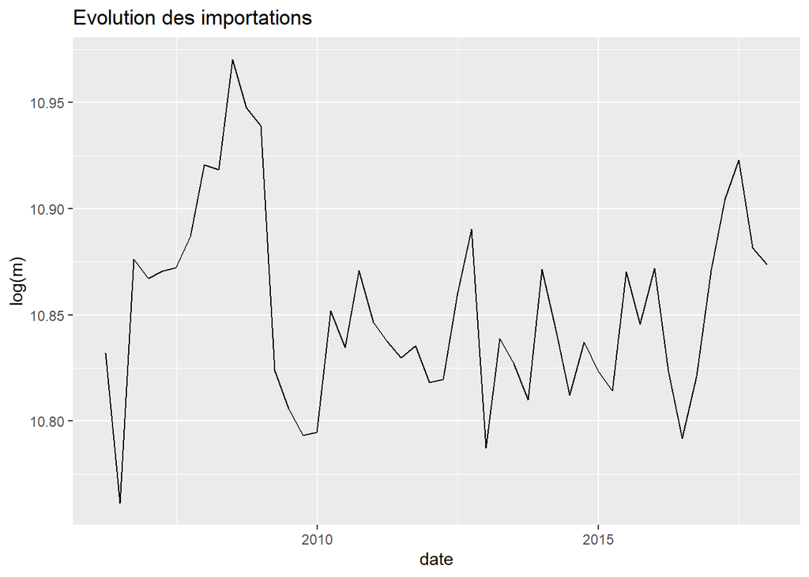

```r
ggplot(data = dt_pf2
       , aes(x =date, y=log(m))) +
  geom_line() +
  ggtitle(paste0("Evolution des importations"))
```

```r
a <- ur.df(log(dt_pf2$m),
           lags = 6,
           selectlags = "AIC",
           type = "trend")
summary(a)
```

```
##
## ###############################################
## # Augmented Dickey-Fuller Test Unit Root Test #
## ###############################################
##
## Test regression trend
##
##
## Call:
## lm(formula = z.diff ~ z.lag.1 + 1 + tt + z.diff.lag)
##
## Residuals:
##       Min        1Q    Median        3Q       Max
## -0.098646 -0.018433 -0.002824  0.023183  0.070872
##
## Coefficients:
##               Estimate Std. Error t value Pr(>|t|)
## (Intercept)  7.0299772  2.1165249   3.321  0.00210 **
## z.lag.1     -0.6464866  0.1944365  -3.325  0.00208 **
## tt          -0.0005492  0.0005361  -1.024  0.31266
## z.diff.lag1  0.2255209  0.1901007   1.186  0.24349
## z.diff.lag2  0.3381765  0.1905249   1.775  0.08460 .
## z.diff.lag3  0.2479462  0.1772739   1.399  0.17071
## ---
## Signif. codes:  0 '***' 0.001 '**' 0.01 '*' 0.05 '.' 0.1 ' ' 1
##
## Residual standard error: 0.03576 on 35 degrees of freedom
## Multiple R-squared:  0.2682, Adjusted R-squared:  0.1637
## F-statistic: 2.566 on 5 and 35 DF,  p-value: 0.04437
##
##
## Value of test-statistic is: -3.3249 3.7831 5.6741
##
## Critical values for test statistics:
##       1pct  5pct 10pct
## tau3 -4.15 -3.50 -3.18
## phi2  7.02  5.13  4.31
## phi3  9.31  6.73  5.61
```

```r
b <- ur.df(log(dt_pf2$m),
           lags = 6,
           selectlags = "AIC",
           type = "drift")
summary(b)
```

```
##
## ###############################################
## # Augmented Dickey-Fuller Test Unit Root Test #
## ###############################################
##
## Test regression drift
##
##
## Call:
## lm(formula = z.diff ~ z.lag.1 + 1 + z.diff.lag)
##
## Residuals:
##      Min       1Q   Median       3Q      Max
## -0.08914 -0.02090 -0.01041  0.02969  0.07762
##
## Coefficients:
##             Estimate Std. Error t value Pr(>|t|)
## (Intercept)  4.19973    1.51465   2.773  0.00856 **
## z.lag.1     -0.38700    0.13956  -2.773  0.00856 **
## z.diff.lag   0.03077    0.16181   0.190  0.85018
## ---
## Signif. codes:  0 '***' 0.001 '**' 0.01 '*' 0.05 '.' 0.1 ' ' 1
##
## Residual standard error: 0.03609 on 38 degrees of freedom
## Multiple R-squared:  0.1908, Adjusted R-squared:  0.1482
## F-statistic: 4.479 on 2 and 38 DF,  p-value: 0.01793
##
##
## Value of test-statistic is: -2.773 3.8459
##
## Critical values for test statistics:
##       1pct  5pct 10pct
## tau2 -3.58 -2.93 -2.60
## phi1  7.06  4.86  3.94
```

```r
c <- ur.df(log(dt_pf2$m),
           lags = 6,
           selectlags = "AIC",
           type = "none")
summary(c)
```

```
##
## ###############################################
## # Augmented Dickey-Fuller Test Unit Root Test #
## ###############################################
##
## Test regression none
##
##
## Call:
## lm(formula = z.diff ~ z.lag.1 - 1 + z.diff.lag)
##
## Residuals:
##       Min        1Q    Median        3Q       Max
## -0.111444 -0.018428  0.005859  0.019138  0.058868
##
## Coefficients:
##                Estimate  Std. Error t value Pr(>|t|)
## z.lag.1     -0.00001859  0.00053195  -0.035  0.97232
## z.diff.lag1 -0.19134717  0.15159395  -1.262  0.21498
## z.diff.lag2 -0.03566405  0.15569538  -0.229  0.82012
## z.diff.lag3 -0.13395570  0.15611545  -0.858  0.39654
## z.diff.lag4 -0.42562132  0.15559805  -2.735  0.00961 **
## ---
## Signif. codes:  0 '***' 0.001 '**' 0.01 '*' 0.05 '.' 0.1 ' ' 1
##
## Residual standard error: 0.03692 on 36 degrees of freedom
## Multiple R-squared:  0.1978, Adjusted R-squared:  0.08635
## F-statistic: 1.775 on 5 and 36 DF,  p-value: 0.1429
##
##
## Value of test-statistic is: -0.0349
##
## Critical values for test statistics:
##       1pct  5pct 10pct
## tau1 -2.62 -1.95 -1.61
```

Nous acceptons l’hypothèse nulle de non-stationarité dans un modèle sans constante ni dérive temporelle.

## 11.2 `df`

La demande finale, i.e. tout les postes de la demande du PIB sauf les importations, est censée être un bon indicateur de la demande de resssources extérieure.

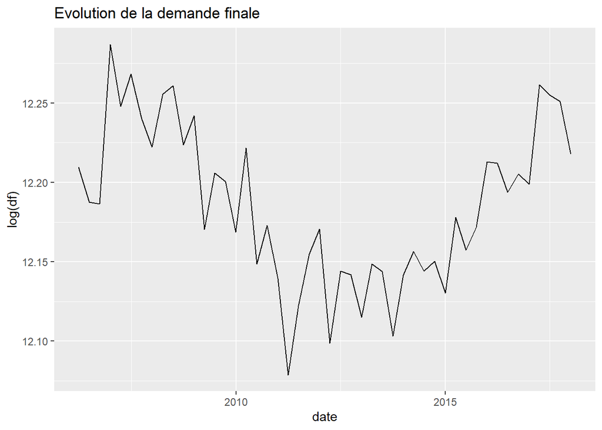

```r
ggplot(data = dt_pf2
       , aes(x =date, y=log(df))) +
  geom_line() +
  ggtitle(paste0("Evolution de la demande finale"))
```

```r
a <- ur.df(log(dt_pf2$df),
           lags = 6,
           selectlags = "AIC",
           type = "trend")
summary(a)
```

```
##
## ###############################################
## # Augmented Dickey-Fuller Test Unit Root Test #
## ###############################################
##
## Test regression trend
##
##
## Call:
## lm(formula = z.diff ~ z.lag.1 + 1 + tt + z.diff.lag)
##
## Residuals:
##      Min       1Q   Median       3Q      Max
## -0.07111 -0.01713  0.00281  0.02477  0.04110
##
## Coefficients:
##               Estimate Std. Error t value Pr(>|t|)
## (Intercept)  0.1518375  1.4857122   0.102   0.9192
## z.lag.1     -0.0155785  0.1214891  -0.128   0.8987
## tt           0.0013705  0.0005344   2.564   0.0149 *
## z.diff.lag1 -0.7177176  0.2047119  -3.506   0.0013 **
## z.diff.lag2 -0.5979565  0.2304813  -2.594   0.0139 *
## z.diff.lag3 -0.3746830  0.2214756  -1.692   0.0998 .
## z.diff.lag4 -0.3132926  0.1568760  -1.997   0.0539 .
## ---
## Signif. codes:  0 '***' 0.001 '**' 0.01 '*' 0.05 '.' 0.1 ' ' 1
##
## Residual standard error: 0.02954 on 34 degrees of freedom
## Multiple R-squared:  0.4142, Adjusted R-squared:  0.3109
## F-statistic: 4.007 on 6 and 34 DF,  p-value: 0.003861
##
##
## Value of test-statistic is: -0.1282 2.7799 4.1583
##
## Critical values for test statistics:
##       1pct  5pct 10pct
## tau3 -4.15 -3.50 -3.18
## phi2  7.02  5.13  4.31
## phi3  9.31  6.73  5.61
```

```r
b <- ur.df(log(dt_pf2$df),
           lags = 6,
           selectlags = "AIC",
           type = "drift")
summary(b)
```

```
##
## ###############################################
## # Augmented Dickey-Fuller Test Unit Root Test #
## ###############################################
##
## Test regression drift
##
##
## Call:
## lm(formula = z.diff ~ z.lag.1 + 1 + z.diff.lag)
##
## Residuals:
##       Min        1Q    Median        3Q       Max
## -0.075525 -0.014678 -0.000365  0.020300  0.066389
##
## Coefficients:
##             Estimate Std. Error t value Pr(>|t|)
## (Intercept)   1.9955     1.3855   1.440   0.1582
## z.lag.1      -0.1639     0.1138  -1.441   0.1581
## z.diff.lag1  -0.4315     0.1706  -2.529   0.0158 *
## z.diff.lag2  -0.2213     0.1597  -1.386   0.1740
## ---
## Signif. codes:  0 '***' 0.001 '**' 0.01 '*' 0.05 '.' 0.1 ' ' 1
##
## Residual standard error: 0.03151 on 37 degrees of freedom
## Multiple R-squared:  0.2748, Adjusted R-squared:  0.216
## F-statistic: 4.673 on 3 and 37 DF,  p-value: 0.007239
##
##
## Value of test-statistic is: -1.4408 1.0487
##
## Critical values for test statistics:
##       1pct  5pct 10pct
## tau2 -3.58 -2.93 -2.60
## phi1  7.06  4.86  3.94
```

```r
c <- ur.df(log(dt_pf2$df),
           lags = 6,
           selectlags = "AIC",
           type = "none")
summary(c)
```

```
##
## ###############################################
## # Augmented Dickey-Fuller Test Unit Root Test #
## ###############################################
##
## Test regression none
##
##
## Call:
## lm(formula = z.diff ~ z.lag.1 - 1 + z.diff.lag)
##
## Residuals:
##       Min        1Q    Median        3Q       Max
## -0.071642 -0.019361  0.002678  0.018839  0.063098
##
## Coefficients:
##                Estimate  Std. Error t value Pr(>|t|)
## z.lag.1     -0.00006141  0.00040977  -0.150  0.88166
## z.diff.lag1 -0.53336523  0.15742194  -3.388  0.00165 **
## z.diff.lag2 -0.27863459  0.15679453  -1.777  0.08356 .
## ---
## Signif. codes:  0 '***' 0.001 '**' 0.01 '*' 0.05 '.' 0.1 ' ' 1
##
## Residual standard error: 0.03195 on 38 degrees of freedom
## Multiple R-squared:  0.2343, Adjusted R-squared:  0.1739
## F-statistic: 3.876 on 3 and 38 DF,  p-value: 0.01637
##
##
## Value of test-statistic is: -0.1499
##
## Critical values for test statistics:
##       1pct  5pct 10pct
## tau1 -2.62 -1.95 -1.61
```

Nous acceptons l’hypothèse nulle de non-stationarité dans un modèle sans constante ni dérive temporelle.

## 11.3 Regression de la relation de long terme

```r
reg_m_lt1 <- lm(log(m) ~ log(df), dt_pf2)
summary(reg_m_lt1)
```

```
##
## Call:
## lm(formula = log(m) ~ log(df), data = dt_pf2)
##
## Residuals:
##       Min        1Q    Median        3Q       Max
## -0.091900 -0.022513  0.001498  0.023910  0.080629
##
## Coefficients:
##             Estimate Std. Error t value Pr(>|t|)
## (Intercept)   4.8155     1.3266   3.630  0.00071 ***
## log(df)       0.4954     0.1089   4.551 0.000039 ***
## ---
## Signif. codes:  0 '***' 0.001 '**' 0.01 '*' 0.05 '.' 0.1 ' ' 1
##
## Residual standard error: 0.03736 on 46 degrees of freedom
## Multiple R-squared:  0.3104, Adjusted R-squared:  0.2954
## F-statistic: 20.71 on 1 and 46 DF,  p-value: 0.00003901
```

La régression est acceptable (R<sup>2</sup> faible à cause des ocsillations).

## 11.4 Tests de cointégration

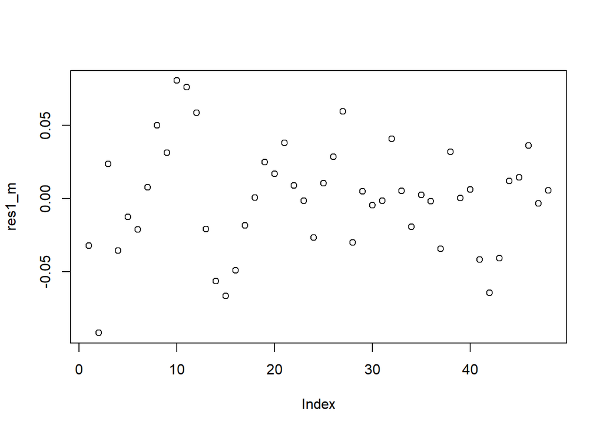

```r
res1_m <- resid(reg_m_lt1)
plot(res1_m)
```

```r
reg_m_res1 <-
  ur.df(res1_m,
        lags = 6,
        type = "none",
        selectlags = "AIC")
summary(reg_m_res1)
```

```
##
## ###############################################
## # Augmented Dickey-Fuller Test Unit Root Test #
## ###############################################
##
## Test regression none
##
##
## Call:
## lm(formula = z.diff ~ z.lag.1 - 1 + z.diff.lag)
##
## Residuals:
##       Min        1Q    Median        3Q       Max
## -0.062464 -0.014370 -0.003801  0.025325  0.061108
##
## Coefficients:
##             Estimate Std. Error t value Pr(>|t|)
## z.lag.1      -0.7150     0.1642  -4.355 0.000097 ***
## z.diff.lag1   0.2760     0.1594   1.731   0.0915 .
## z.diff.lag2   0.3697     0.1530   2.417   0.0205 *
## ---
## Signif. codes:  0 '***' 0.001 '**' 0.01 '*' 0.05 '.' 0.1 ' ' 1
##
## Residual standard error: 0.02875 on 38 degrees of freedom
## Multiple R-squared:  0.3445, Adjusted R-squared:  0.2927
## F-statistic: 6.656 on 3 and 38 DF,  p-value: 0.001008
##
##
## Value of test-statistic is: -4.3554
##
## Critical values for test statistics:
##       1pct  5pct 10pct
## tau1 -2.62 -1.95 -1.61
```

Nous rejetons l’hypothèse nulle d’absence de cointégration.

## 11.5 Détermination de la spécification

Nous estimons sans l’année 2018.

```r
create_equation(
  equation_name = "eq_m",
  formula = "delta(1,log(m))=j_cst+j_0*(log(lag(m,-1))-j_lt1-j_lt2*log(lag(df,-1)))+j_1*delta(1,log(df))+delta(1,af_eq_m)-j_0*lag(af_eq_m,-1)",
  coefflist = c("j_cst", "j_0", "j_1", "j_2", "j_3", "j_lt2", "j_lt1", "j_lt3"),
  endogenous = "m"
)
```

```
## The following coefficients were not found in the formula:[1] "j_2"   "j_3"   "j_lt3"
##
## Equation variables identified :
## af_eq_m df j_0 j_1 j_cst j_lt1 j_lt2 m
##  Exogenous variables :
## af_eq_m df
##  Coefficients parser error, the formula may be difficult to use in econometric estimations.
##  RHS of equation does not appear to be ok for econometric estimations with the current coefficient list.
```

```r
estimation <-
  quick_estim(
    thor_equation = eq_m ,
    database = dt_pf,
    estim_start = as.Date(date_debut_estim),
    estim_end = as.Date("2017-12-31"),
    coeff_lt = c("j_lt1", "j_lt2"),
    const = T
  )
```

```
##
##  --------------- Estimating equation: eq_m ---------------
##
##
##  Estimation du long-terme :
##
## ### D-OLS model ###
##
## Model:       sub_database[c(index_start:index_end), yt] ~ c(rep(1, (index_end - index_start + 1))) + sub_database[c(index_start:index_end), xt]
##
## Parameters:  Kernel = "qs"  //  Bandwidth = 4.794423 ("Andrews")
##
##      Leads = 2 / Lags = 2 (set manually)
##
## Coefficients:
##         Estimate Std.Err t value Pr(|t|>0)
## deter    4.66738 2.02780  2.3017  0.025390 *
## x.coint  0.50754 0.16639  3.0503  0.003593 **
## ---
## Signif. codes:  0 '***' 0.001 '**' 0.01 '*' 0.05 '.' 0.1 ' ' 1
## delta(1,log(m))=j_cst+j_0*(log(lag(m,-1))-4.6673801439-0.5075435527*log(lag(df,-1)))+j_1*delta(1,log(df))+delta(1,af_eq_m)-j_0*lag(af_eq_m,-1)
##
##  Estimation du court-terme :
##
## Call:
## lm(formula = eval(parse(text = formula_ols)), data = plop)
##
## Residuals:
##       Min        1Q    Median        3Q       Max
## -0.078826 -0.020856  0.001974  0.024501  0.065636
##
## Coefficients: (1 not defined because of singularities)
##                                                                     Estimate
## (Intercept)                                                        0.0004564
## I(log(lag(m, 1)) - 4.6673801439 - 0.5075435527 * log(lag(df, 1))) -0.5390561
## newdiff(1, log(df))                                                0.4391251
## newdiff(1, af_eq_m)                                                       NA
##                                                                   Std. Error
## (Intercept)                                                        0.0048279
## I(log(lag(m, 1)) - 4.6673801439 - 0.5075435527 * log(lag(df, 1)))  0.1313383
## newdiff(1, log(df))                                                0.1323983
## newdiff(1, af_eq_m)                                                       NA
##                                                                   t value
## (Intercept)                                                         0.095
## I(log(lag(m, 1)) - 4.6673801439 - 0.5075435527 * log(lag(df, 1)))  -4.104
## newdiff(1, log(df))                                                 3.317
## newdiff(1, af_eq_m)                                                    NA
##                                                                   Pr(>|t|)
## (Intercept)                                                       0.925108
## I(log(lag(m, 1)) - 4.6673801439 - 0.5075435527 * log(lag(df, 1))) 0.000168 ***
## newdiff(1, log(df))                                               0.001808 **
## newdiff(1, af_eq_m)                                                     NA
## ---
## Signif. codes:  0 '***' 0.001 '**' 0.01 '*' 0.05 '.' 0.1 ' ' 1
##
## Residual standard error: 0.03344 on 45 degrees of freedom
##   (1 observation effacée parce que manquante)
## Multiple R-squared:  0.3683, Adjusted R-squared:  0.3402
## F-statistic: 13.12 on 2 and 45 DF,  p-value: 0.00003247
```

```r
create_equation(
  equation_name = "eq_m",
  formula = "delta(1,log(m))=j_cst+j_0*(log(lag(m,-1))-j_lt1-j_lt2*log(lag(df,-1)))+j_1*delta(1,log(df))+j_2*delta(1,log(tcen))+delta(1,af_eq_m)-j_0*lag(af_eq_m,-1)",
  coefflist = c("j_cst", "j_0", "j_1", "j_2", "j_3", "j_lt2", "j_lt1", "j_lt3"),
  endogenous = "m"
)
```

```
## The following coefficients were not found in the formula:[1] "j_3"   "j_lt3"
##
## Equation variables identified :
## af_eq_m df j_0 j_1 j_2 j_cst j_lt1 j_lt2 m tcen
##  Exogenous variables :
## af_eq_m df tcen
##  Coefficients parser error, the formula may be difficult to use in econometric estimations.
##  RHS of equation does not appear to be ok for econometric estimations with the current coefficient list.
```

```r
estimation <-
  quick_estim(
    thor_equation = eq_m ,
    database = dt_pf,
    estim_start = as.Date(date_debut_estim),
    estim_end = as.Date("2017-12-31"),
    coeff_lt = c("j_lt1", "j_lt2"),
    const = T
  )
```

```
##
##  --------------- Estimating equation: eq_m ---------------
##
##
##  Estimation du long-terme :
##
## ### D-OLS model ###
##
## Model:       sub_database[c(index_start:index_end), yt] ~ c(rep(1, (index_end - index_start + 1))) + sub_database[c(index_start:index_end), xt]
##
## Parameters:  Kernel = "qs"  //  Bandwidth = 4.794423 ("Andrews")
##
##      Leads = 2 / Lags = 2 (set manually)
##
## Coefficients:
##         Estimate Std.Err t value Pr(|t|>0)
## deter    4.66738 2.02780  2.3017  0.025390 *
## x.coint  0.50754 0.16639  3.0503  0.003593 **
## ---
## Signif. codes:  0 '***' 0.001 '**' 0.01 '*' 0.05 '.' 0.1 ' ' 1
## delta(1,log(m))=j_cst+j_0*(log(lag(m,-1))-4.6673801439-0.5075435527*log(lag(df,-1)))+j_1*delta(1,log(df))+j_2*delta(1,log(tcen))+delta(1,af_eq_m)-j_0*lag(af_eq_m,-1)
##
##  Estimation du court-terme :
##
## Call:
## lm(formula = eval(parse(text = formula_ols)), data = plop)
##
## Residuals:
##       Min        1Q    Median        3Q       Max
## -0.073834 -0.017720  0.000329  0.023028  0.070958
##
## Coefficients: (1 not defined because of singularities)
##                                                                     Estimate
## (Intercept)                                                        0.0004276
## I(log(lag(m, 1)) - 4.6673801439 - 0.5075435527 * log(lag(df, 1))) -0.5492602
## newdiff(1, log(df))                                                0.4348459
## newdiff(1, log(tcen))                                             -0.1218463
## newdiff(1, af_eq_m)                                                       NA
##                                                                   Std. Error
## (Intercept)                                                        0.0048238
```

[output cut: 8 more lines]

```
## newdiff(1, log(tcen))                                              -1.038
## newdiff(1, af_eq_m)                                                    NA
##                                                                   Pr(>|t|)
## (Intercept)                                                       0.929764
## I(log(lag(m, 1)) - 4.6673801439 - 0.5075435527 * log(lag(df, 1))) 0.000139 ***
## newdiff(1, log(df))                                               0.002003 **
## newdiff(1, log(tcen))                                             0.305025
## newdiff(1, af_eq_m)                                                     NA
## ---
## Signif. codes:  0 '***' 0.001 '**' 0.01 '*' 0.05 '.' 0.1 ' ' 1
##
## Residual standard error: 0.03342 on 44 degrees of freedom
##   (1 observation effacée parce que manquante)
## Multiple R-squared:  0.3834, Adjusted R-squared:  0.3414
## F-statistic: 9.119 on 3 and 44 DF,  p-value: 0.00008268
```

Nous gardons cette seconde spécification car elle augmente le R<sup>2</sup> ajusté même si le coefficient de `tcen` n’est pas significatif.

# 12 Code exemple pour présentation

## 12.1 Equations latex

Il est possible d’obtenir le code nécessaire à l’affichage des équations en Latex. Voici un exemple :

```r
cat(formula_latex(eq_m))
```

[output not shown]

$$\Delta_{1}( \mathit{log(} \textbf{m}_{t}
))= \textit{j_cst} + \textit{j_0} *( \mathit{log(} \textbf{m}_{t-1} )-
\textit{j_lt1} - \textit{j_lt2} * \mathit{log(} \textbf{df}_{t-1} ))+
\textit{j_1} * \Delta_{1}( \mathit{log(} \textbf{df}_{t} ))+
\textit{j_2} * \Delta_{1}( \mathit{log(} \textbf{tcen}_{t} ))+
\Delta_{1}( \textbf{af_eq_m}_{t} )- \textit{j_0} *
\textbf{af_eq_m}_{t-1}$$

## 12.2 Présentation résultat régression

Pour comparer les régressions et mettre en page, la fonction `stargazer()` est intéressante.

Par exemple pour `eq_ipc_nrj` :

```r
stargazer(reg_ipc_nrj_lt1,reg_ipc_nrj_lt2,reg_ipc_nrj_lt3,
          title="Regression Results",
          align=TRUE,
          omit.stat=c("LL","ser","f"),
          no.space=TRUE,
          type="text")
```

```
##
## Regression Results
## ==========================================
##                   Dependent variable:
##              -----------------------------
##                      log(ipc_nrj)
##                 (1)       (2)       (3)
## ------------------------------------------
## log(petrole) 0.399***            0.387***
##               (0.056)             (0.039)
## log(brent)             0.132***  0.125***
##                         (0.029)   (0.017)
## Constant     2.808***  4.086***  2.328***
##               (0.258)   (0.126)   (0.191)
## ------------------------------------------
## Observations    52        52        52
## R2             0.507     0.292     0.766
## Adjusted R2    0.497     0.278     0.757
## ==========================================
## Note:          *p<0.1; **p<0.05; ***p<0.01
```

Il est également possible d’obtenir le code `LateX` :

```r
stargazer(reg_ipc_nrj_lt1,reg_ipc_nrj_lt2,reg_ipc_nrj_lt3,
          title="Regression Results",
          align=TRUE,
          omit.stat=c("LL","ser","f"),
          no.space=TRUE,
          type="latex")
```